# Loans data: first look

Dzianis Sokalau

6/25/2017

Loan is cool thing for both lender and borrower. For lender it is tool for making money. For borrower it is opportynity to have things (business, having a home or car, education)

The issue is that some loans are going to be paid and some aren’t  
and challenge is find how to predict future status of a loan

This script is for take first look to the loans’ data

The data is from https://www.kaggle.com/wendykan/lending-club-loan-data  
Original source is Lending Club: https://www.lendingclub.com/info/download-data.action

### Let’s take a look what variables are in the data

we have already stored data into df

```r
colnames(df)
```

```
##  [1] "id"                          "member_id"
##  [3] "loan_amnt"                   "funded_amnt"
##  [5] "funded_amnt_inv"             "term"
##  [7] "int_rate"                    "installment"
##  [9] "grade"                       "sub_grade"
## [11] "emp_title"                   "emp_length"
## [13] "home_ownership"              "annual_inc"
## [15] "verification_status"         "issue_d"
## [17] "loan_status"                 "pymnt_plan"
## [19] "url"                         "desc"
## [21] "purpose"                     "title"
## [23] "zip_code"                    "addr_state"
## [25] "dti"                         "delinq_2yrs"
## [27] "earliest_cr_line"            "inq_last_6mths"
## [29] "mths_since_last_delinq"      "mths_since_last_record"
```

[output cut: 22 more lines]

There are a lot of information in the table. Since in the current script we want just make first exploration, we will consider some of them:  
loan_status - current status of the loan  
loan_amnt - the listed amount of the loan applied for by the borrower. If at some point in time, the credit department reduces the loan amount, then it will be reflected in this value  
purpose - A category provided by the borrower for the loan request  
annual_inc - the self-reported annual income provided by the borrower during registration  
dti - a ratio calculated using the borrower's total monthly debt payments on the total debt obligations, excluding mortgage and the requested LC loan, divided by the borrower's self-reported monthly income  
int_rate - interest Rate on the loan

### What are the loans statuses and what the frequency of each status

```r
l_status <- df %>%
                group_by(loan_status) %>%
                summarise(count = n() / 1000) %>%
                arrange(desc(count))

l_status
```

```
## # A tibble: 10 x 2
##                                            loan_status   count
##                                                  <chr>   <dbl>
##  1                                             Current 601.779
##  2                                          Fully Paid 207.723
##  3                                         Charged Off  45.248
##  4                                  Late (31-120 days)  11.591
##  5                                              Issued   8.460
##  6                                     In Grace Period   6.253
##  7                                   Late (16-30 days)   2.357
##  8  Does not meet the credit policy. Status:Fully Paid   1.988
##  9                                             Default   1.219
## 10 Does not meet the credit policy. Status:Charged Off   0.761
```

In this case we should compare only closed loans or already more likely to be bad loans Bad loans are “Default”, “Charged Off” and “Late (31-120 days)” Good loans are those were fully paid - “Fully Paid”

```r
b_loans <- c("Charged Off",
              "Late (31-120 days)",
              "Default")
g_loans <- "Fully Paid"
l_status <- l_status[l_status$loan_status %in% c(unlist(b_loans), g_loans),]
l_status <- transform(l_status,
                      loan_status = reorder(loan_status, desc(count)))
```

### And what we have now is on the chart bellow

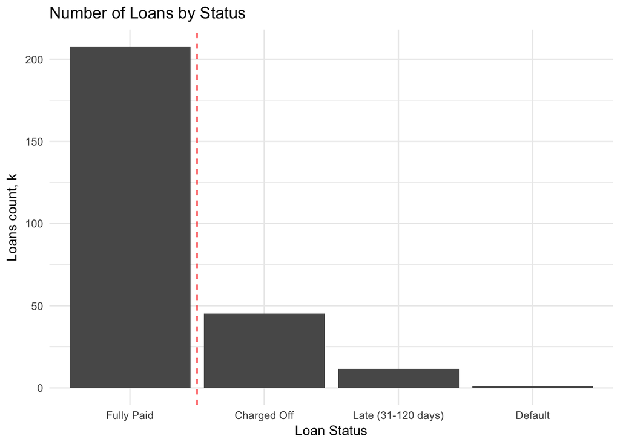

```r
ggplot(l_status, aes(x=loan_status, y=count)) +
  geom_bar(stat = "identity") +
  labs(title="Number of Loans by Status", x = "Loan Status", y = "Loans count, k") +
  geom_vline(xintercept = 1.5, linetype="dashed", color = "red", size = 0.5) +
  theme_minimal()
```

The red dashed line on the chart separates good from bad loans

### According to the data share of bad loans is around 22%

```r
sum(l_status[l_status$loan_status %in% b_loans, 'count'])/
  sum(l_status[l_status$loan_status %in% c(unlist(b_loans), g_loans), 'count'])
```

```
## [1] 0.218443
```

Now we should remain only closed loans in the table. In addition we will create new variable “result” with 0 for bad loans and 1 for good loans. It will help us in the future to calculate probability for loan to be paid depends on different factors

```r
df <- df[df$loan_status %in% c(unlist(b_loans), g_loans),]
df$result <- 1
df[df$loan_status %in% b_loans, 'result'] <- 0
```

### Loans’ amount

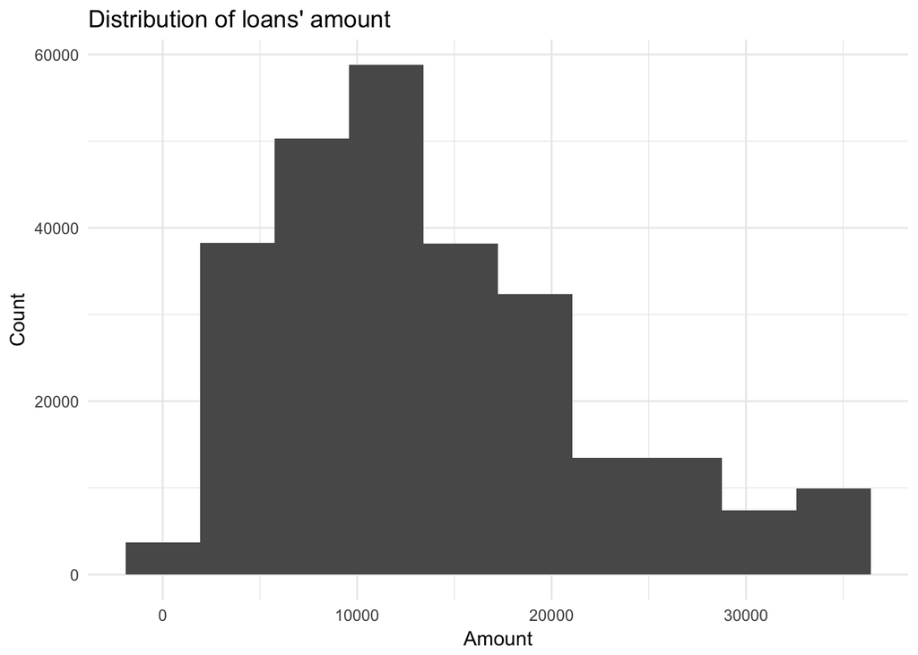

```r
ggplot(df, aes(loan_amnt)) +
  geom_histogram(bins = 10) +
  labs(title="Distribution of loans' amount", x="Amount", y="Count") +
  theme_minimal()
```

It is intresting that people more often borrow not exact amounts  
but equal to whole number in thousands

```r
df %>%
  group_by(loan_amnt) %>%
  summarise(count = n()) %>%
  arrange(desc(count))
```

```
## # A tibble: 1,334 x 2
##    loan_amnt count
##        <dbl> <int>
##  1     10000 18892
##  2     12000 14679
##  3     15000 12665
##  4     20000 11746
##  5      8000  9055
##  6      6000  8728
##  7     35000  8663
##  8      5000  8345
##  9     16000  6596
## 10     18000  6048
## # ... with 1,324 more rows
```

Let’s increase number of bars to show this

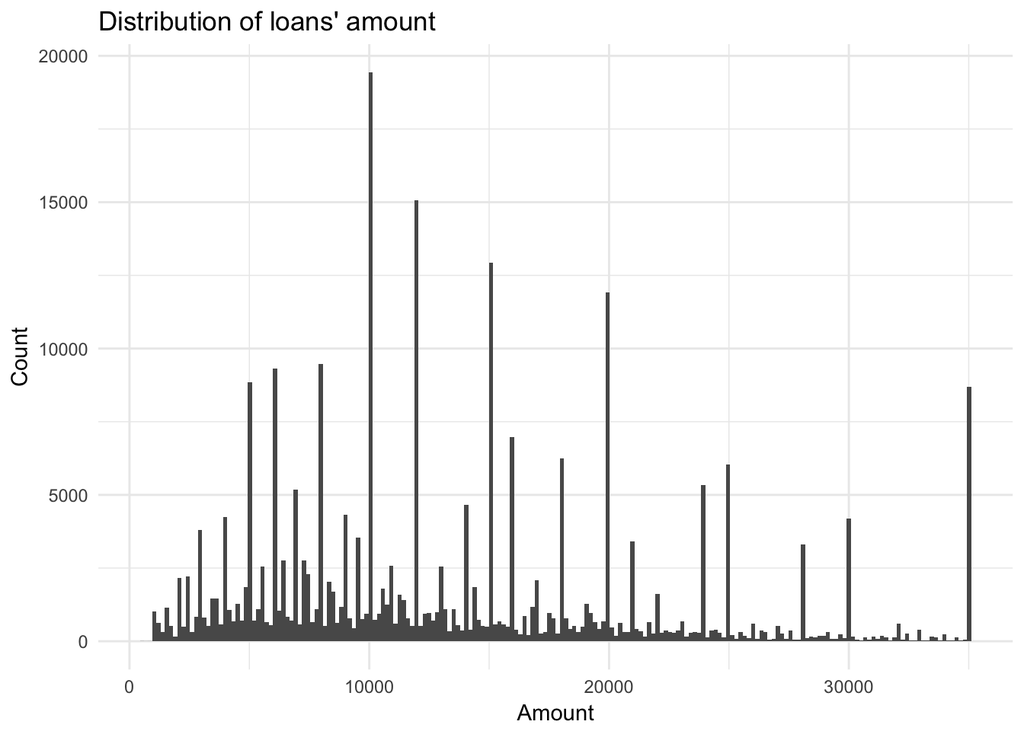

```r
ggplot(df, aes(loan_amnt)) +
  geom_histogram(bins = 200) +
  labs(title="Distribution of loans' amount", x="Amount", y="Count") +
  theme_minimal()
```

You can see peaks on 5000, 6000, 8000, 10000 etc. The most frequent amount is 10,000  
Probably people more often round amount they need

### Some factors on loans’ status

Just as an example let’s take a look on what factors may impact on loans quality  
bellow we consider such variables like loan amount, annual income of borrower, dti and interst rate

```r
df %>%
  group_by(loan_status) %>%
  summarise(count = n(),
            med_amount = median(loan_amnt),
            med_inc = median(annual_inc),
            med_dti = median(dti),
            med_int = median(int_rate)) %>%
  arrange(desc(count))
```

```
## # A tibble: 4 x 6
##          loan_status  count med_amount med_inc med_dti med_int
##                <chr>  <int>      <dbl>   <dbl>   <dbl>   <dbl>
## 1         Fully Paid 207723      12000   64162   15.75   13.11
## 2        Charged Off  45248      12675   56000   18.35   15.80
## 3 Late (31-120 days)  11591      14000   60000   19.57   15.61
## 4            Default   1219      13675   56000   19.84   15.99
```

Let’s translate this numbers into visualization

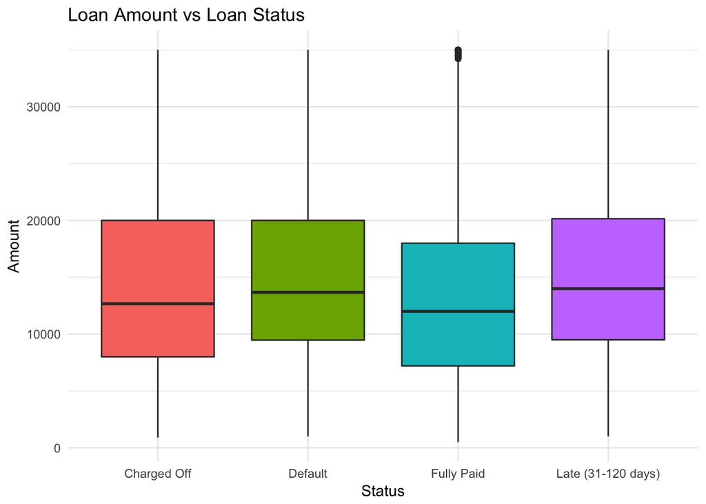

```r
ggplot(df, aes(loan_status, loan_amnt, fill = as.factor(loan_status))) +
  geom_boxplot() +
  labs(title="Loan Amount vs Loan Status", x="Status", y="Amount") +
  theme_minimal() +
  theme(legend.position = "none")
```

And nothing special here, amount for fully paid loans a little bit lower than for others

The similar thing is for borrower income:  
it is a little bit higher for thouse who paid loan successfully

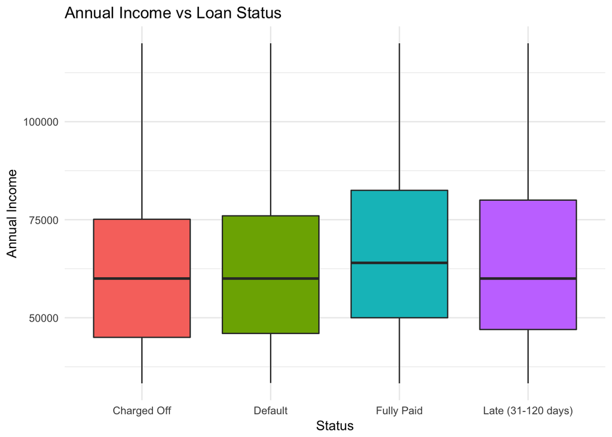

```r
ggplot(df, aes(loan_status, annual_inc, fill = as.factor(loan_status))) +
  geom_boxplot() +
  scale_y_continuous(limits = quantile(df$annual_inc, c(0.1, 0.9), na.rm = T)) +
  labs(title="Annual Income vs Loan Status", x="Status", y="Annual Income") +
  theme_minimal() +
  theme(legend.position = "none")
```

The last thing I’m going to consider today is interest rate. It depends on grade and subgrade of borrower: the more risky borrower the higher inters rate  
on the other hand. Interesting thing is the higher interest rate the more complicated to pay loan

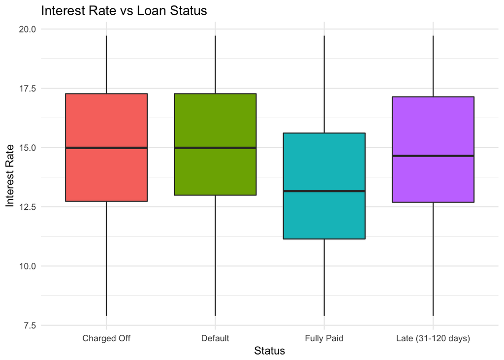

```r
ggplot(df, aes(loan_status, int_rate, fill = as.factor(loan_status))) +
  geom_boxplot() +
  scale_y_continuous(limits = quantile(df$int_rate, c(0.1, 0.9))) +
  labs(title="Interest Rate vs Loan Status", x="Status", y="Interest Rate") +
  theme_minimal() +
  theme(legend.position = "none")
```

Abowe I considered some of the loans data variables  
Next time I’m going to dive dipper in the data and explain which of the variables in the data set may be used for a real word scorring application

### Continuation

2nd article about features exploration is [here](https://dzianissokalau.github.io/projects/loans/2-loans-data-features-exploration.html)  
you can also check for updates  
here: https://www.linkedin.com/in/dzianis-sokalau-83454a3b/  
or here: https://twitter.com/ptyshka